# Settlement Persistence Project, SBOM Script #4:

Catchment Territories, Transport and Spatial Network Models

Rudolf Cesaretti

Last run on 2022-07-03

I do five things in this R markdown document:

1. Create site catchment areas
2. Calculate catchment area transport route densities
3. Calculate catchment area demographic densities
4. Define spatial network models for AggSites/Catchments and associated metrics
5. Reorganize the data and export for Script #5

# 1 Setup

All of the data and scripts are downloadable from the [new ASU SettlementPersist2022 github repository](https://https://github.com/rcesaret/ASUSettlementPersist2022), which can be downloaded locally as a .zip folder or cloned to your own account.

Either way, once you have done so, you will need to modify the working directory (setwd(“C:/…)”) path and “dir” variables in the code chunk below to match the repository location on your computer.

```r
wd <- list()

# SET YOUR LOCAL DIRECTORY LOCATION HERE:
wd$dir <- "C:/Users/rcesaret/Dropbox (ASU)/ASUSettlementPersist2022/"
# wd$dir <- 'C:/Users/TJ McMote/Dropbox (ASU)/ASUSettlementPersist2022'

wd$analysis <- paste0(wd$dir, "analysis/")
wd$data_r <- paste0(wd$dir, "data-raw/")
wd$data_p <- paste0(wd$dir, "data-processed/")
wd$data_f <- paste0(wd$dir, "data-final-outputs/")
wd$figs <- paste0(wd$dir, "figures/")
wd$funcs <- paste0(wd$dir, "functions/")
```

## 1.1 Load R Packages and Custom Functions

```r
# Package names
packages <- c("rgdal", "rgeos", "sp", "sf", "GISTools", "raster", "Matrix",
    "gdistance", "lwgeom", "tidyverse", "tidyr", "stars", "dismo", "purrr",
    "spatialEco", "whitebox", "classInt")  #, 'data.table', 'zoo', 'era', 'JOPS', 'mgcv','igraph', 'ggnewscale', 'ggrepel','ggridges', 'movecost',  'datplot', 'scales',

# Install packages not yet installed
installed_packages <- packages %in% rownames(installed.packages())
if (any(installed_packages == FALSE)) {
    install.packages(packages[!installed_packages])
}

# load packages
invisible(lapply(packages, library, character.only = TRUE))

rm(packages, installed_packages)

# Read in custom R functions located in the wd$funcs directory folder
FUNCS <- list("splitByAttributes.R", "CatchmentPolys.R")
invisible(lapply(FUNCS, function(x) source(paste0(wd$funcs, x))))
rm(FUNCS)
```

## 1.2 Import Data

Data we are importing:

1. The AggSite polygon data exported from script #2
2. A simple polygon calculated in QGIS that specifies a hard outer border for the catchment areas of sites (constructed for sensitivity to survey borders and sites not included in the SBOM sample)
3. Cost-distance matrices from script #3
4. Least cost path rasters from script #3
5. A raster hillshade basemap for the SBOM which includes the lakes

```r
# Agg Site polygon data
All_AggPoly <- readOGR(paste0(wd$data_p, "SBOM_AggPoly2.gpkg"))
# Catchment boundary limit polygon
CatchLims <- readOGR(paste0(wd$data_r, "CatchLims.gpkg"))
## Hillshade Basemap Raster with lake
HillshadeLake <- raster(paste0(wd$data_r, "HillshadeLake.tif"))
HillshadeLake <- rast(HillshadeLake, crs = 26914)

ord <- c("EF", "EF_MF", "MF", "MF_LF", "LF", "LF_TF", "TF", "TF_CL", "CL", "CL_ET",
    "ET", "ET_LTAzI", "LTAzI", "LTAzI_EA", "EA", "EA_LA", "LA")

# Cost-distance matrices
temp = list.files(path = paste0(wd$data_p, "CDMatrices/"), full.names = TRUE)
nam.distmat = list.files(path = paste0(wd$data_p, "CDMatrices/"), full.names = F)
nam.distmat = gsub("_cdmat.csv", "", nam.distmat)
CD.mats = lapply(temp, read.csv, header = TRUE, row.names = 1)
CD.mats = lapply(CD.mats, as.matrix)
names(CD.mats) <- nam.distmat
CD.mats <- CD.mats[ord]
names(CD.mats) <- paste0(ord, "_cdmat")
# All_Agg_SitePoly <- All_Agg_SitePoly[order(All_Agg_SitePoly$AggSite),]


# Least cost path rasters
temp = list.files(path = paste0(wd$data_p, "lcp_dens_rasts/"), full.names = TRUE,
    pattern = ".grd")
nam.dens = list.files(path = paste0(wd$data_p, "lcp_dens_rasts/"), full.names = F,
    pattern = ".grd")
nam.dens = gsub("_lcpdens.grd", "", nam.dens)
lcp_dens_rasts = lapply(temp, raster)
names(lcp_dens_rasts) <- nam.dens
lcp_dens_rasts <- lcp_dens_rasts[ord]
names(lcp_dens_rasts) <- paste0(ord, "_lcpdens")

rm(temp, nam.distmat, nam.dens, ord)
```

## 1.3 Reorganize Settlement Data from Step #2

```r
# convert spatial polygons dataframe to spatial points dataframe
coor = All_AggPoly@data[, c("East", "North")]  #create separate dataframe of coordinates for spatial points dataframe
rownames(coor) <- as.numeric(rownames(coor))  #make sure rownames match
All_AggPts <- SpatialPointsDataFrame(coor, All_AggPoly@data, match.ID = TRUE)  #convert to spatial points dataframe
proj4string(All_AggPts) <- CRS("+proj=utm +zone=14 +datum=NAD83 +units=m +no_defs")  #make sure CRS matches polygons
All_AggPts = as(st_make_valid(st_as_sf(All_AggPts)), "Spatial")  #make sure geometry is valid

# reorder spatial points dataframe by period
All_AggPts <- All_AggPts[order(All_AggPts$PeriodNum), ]
All_AggPoly <- All_AggPoly[order(All_AggPoly$PeriodNum), ]

# Split points by Phase, saved as list of spatial points dataframes
Pts_List <- splitByAttributes(spdata = All_AggPts, attr = "Period", suffix = "_Pts")
Poly_List <- splitByAttributes(spdata = All_AggPoly, attr = "Period", suffix = "_Poly")

# rename spatial points dataframes to include period numbers as prefix
# PeriodNums <-
# list('1','2','3','4','5','6','7','8','9','10','11','12','13','14','15','16','17')#include
# period number names(Pts_List) <- paste0(PeriodNums,'_',names(Pts_List))
# names(Poly_List) <- paste0(PeriodNums,'_',names(Poly_List))

rm(coor)  # PeriodNums,
```

# 2 Defining Catchment Areas

In order to characterize sites in terms of the characteristics of their immediate hinterlands, we can calculate their ‘catchment areas.’ These are GIS-calculated polygon representing the territorial hinterland of a settlement used for subsistence (etc).

The core method employs a modified version of ‘Voronoi diagrams’ (also known as ‘Thiessen polygons’). Voronoi polygons partition a Euclidean plane into a polygon topology around a set of nodes with equidistant borders between nodes. However, instead of calculating Voronoi polygons from single nodes, the “CatchmentPolys” function uses the borders of site polygons. *To accomplish this, a Voronoi polygon is calculated for each point of a site’s polygon, and then all of the Voronoi polygons belonging to each site are re-aggregated together into a single catchment polygon.* (The script also optionally allows the user to specify normal centroid/node-based Voronoi diagrams.) This method was implemented because of larger (usually urban) settlements in densely settled areas. In such cases, Voronoi polygons using centroid nodes frequently draw catchment borders on the immediate outskirts of sites (or even within the site’s borders). Yet, the catchments of such sites should extend equidistant from the settlement border rather than their polygon centroid. As such, all else being equal, my method makes sure that sites with larger aerial extent will have larger catchment areas. In addition, these Voronoi polygons are restricted to the area within an outer border/limit of the SBOM region (constructed for sensitivity to survey borders and sites not included in the SBOM sample). This is a a simple polygon layer created in QGIS, used as an input to the “CatchmentPolys” function.

Below is an example of the “CatchmentPolys” function and its output:

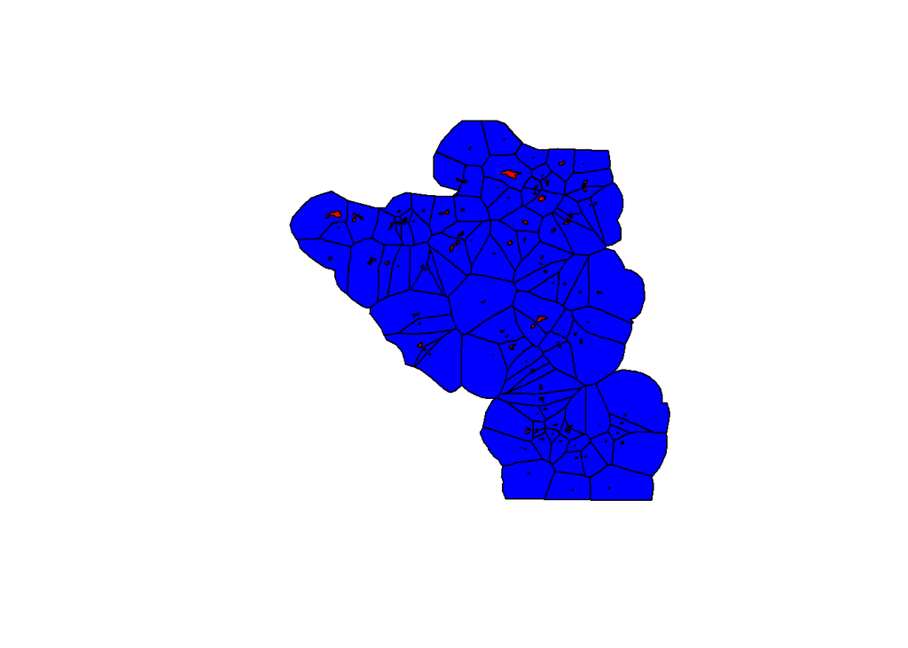

```r
ex1 <- Poly_List[[9]] #choose a period for which to calculate catchments

## Using the CatchmentPolys function

example <- CatchmentPolys(
              sitepolys = ex1, #input polygons from a single period
              border = CatchLims, #input polygon of the hard outer limit
              dist_lim = 5000, # set the radius distance threshold (in meters)
              method = "borders", # choice of method for Voronoi polygons:
              #either "borders" or "centroids" (i.e. Voronoi polygons
              #calculated from the borders of polygons or from their centroids)
              plot.results = F #whetherto output a plot of resulting catchments
              )

#plot results
plot(example,col="blue")
plot(ex1,add=T,col="red")
```

```r
rm(example, ex1)
```

## 2.1 Create Catchment Areas for All Sites/Periods

Having explained the methods and demonstrated the use of the function, we can now calculate catchment areas for all periods by looping over them:

```r
# Define a vector of strings specifying method parameters.  This was done
# because period 14 for some reason was not behaving with the 'borders'
# method. May need to debug the script further...  Regardless, the output
# for this period looks just fine due to the lack of urban sites with
# large areas.
methods <- c("borders", "borders", "borders", "borders", "borders", "borders",
    "borders", "borders", "borders", "borders", "borders", "borders", "borders",
    "centroids", "borders", "borders", "borders")

catch_dist_lim <- 5000  # catchment areas limited to distance of X METERS from borders of site polygon

Catch_List <- list()  #create list to store outputs

for (i in 1:length(Poly_List)) {

    xx = as.character(methods[i])

    catch <- CatchmentPolys(sitepolys = Poly_List[[i]], border = CatchLims,
        dist_lim = catch_dist_lim, method = xx, plot.results = F)

    Catch_List[[i]] <- catch

}

# rename output list objects
sitepoly.names <- names(Poly_List)
sitepoly.names <- gsub("_Poly", "_SitePoly", sitepoly.names)
names(Poly_List) <- sitepoly.names
catch.names <- sitepoly.names
catch.names <- gsub("_SitePoly", "_CatchPoly", catch.names)
names(Catch_List) <- catch.names

rm(methods, catch_dist_lim, xx, catch)
```

# 3 Catchment Area Transport Route Density

Here we calculate the “transport route density” variable for site catchment areas from the least cost path rasters calculated in script #3. This variable gives us a proxy for how central a settlement’s territory may have been to the major transport arteries of a given period.

Transport route density is calculated *in two ways for each period*:

1. as a **percentage of the total** least cost path area (90m x 90m raster cells) in the SBOM
2. as an **ordinal rank** of the above percentages among all site catchments (highest % = 1)

Here, again, we will loop over all periods using the LCP rasters imported from script #3:

```r
Catch_List2 <- list()  #create list for outputs

for (i in 1:length(Catch_List)) {

    # define catchment area polys and LCP rasters from lists as temp
    # objects

    tmp.p <- Catch_List[[i]]
    tmp.p2 <- vect(tmp.p)
    tmp.r <- rast(lcp_dens_rasts[[i]])

    # calculate sum/total LCP area of raster
    sum.lyr <- as.numeric(terra::global(tmp.r, fun = "sum", na.rm = TRUE))

    # calculate transport route density as percentage
    TranspDens.pct <- terra::extract(tmp.r, tmp.p2, fun = sum)  #
    tmp.p@data$TranspDens.pct <- TranspDens.pct[, 2]/sum.lyr * 100

    # calculate transport route density as rank
    tmp.p@data$TranspDens.rank <- rank(-tmp.p@data$TranspDens.pct)

    Catch_List2[[i]] <- tmp.p  #save outputs to list
}

# rename catchment list and its objects accordingly
names(Catch_List2) <- catch.names
Catch_List <- Catch_List2

rm(Catch_List2)
```

# 4 Catchment Area Demographic Densities

Here we calculate catchment population densities – population divided by catchment area (ha) – to provide a proxy for the intensity of land use. In addition to the raw values, relative global values are also calculated. These include the site/catchment’s value (A) as a proportion of the global maximum catchment pop density, and (B) as a global rank of catchment pop density values.

These three metrics are also calculated for the catchment area (ha) beyonjd the site polygon limits (i.e. total catchment area minus site area). This provides an idea of specifically rural land use intensity.

Altogether, the metrics are as follows:

1. **Catch_Popdens.s2** = Catchment Population Density
2. **Catch_Popdens_PropMax.s2** = Catchment Population Density as a proportion of the global maximum
3. **Catch_Popdens_Rank.s2** = Catchment Population Density global rank
4. **CatchB_Popdens.s2** = Catchment Population Density for the area beyond the site polygon
5. **CatchB_Popdens_PropMax.s2** = Catchment Population Density for the area beyond the site polygon as a proportion of the global maximum
6. **CatchB_Popdens_Rank.s2** = Global rank of Catchment Population Density for the area beyond the site polygon

```r
Catch_List2 <- list()  #create output list

for (i in 1:length(Catch_List)) {

    tmp.p <- Catch_List[[i]]  #define catchment area polys as temp object

    tmp.p@data$Catch_Popdens.s2 <- tmp.p@data$Population.s2/tmp.p@data$Catchment_ha

    tmp.p@data$CatchB_Popdens.s2 <- tmp.p@data$Population.s2/tmp.p@data$CatchmentBeyond_ha

    tmp.p@data$Catch_Popdens_PropMax.s2 <- tmp.p@data$Catch_Popdens.s2/(max(tmp.p@data$Catch_Popdens.s2))

    tmp.p@data$Catch_Popdens_Rank.s2 <- rank(-tmp.p@data$Catch_Popdens.s2, na.last = "keep",
        ties.method = "average")

    tmp.p@data$CatchB_Popdens_PropMax.s2 <- (tmp.p@data$CatchB_Popdens.s2/(max(tmp.p@data$CatchB_Popdens.s2)))

    tmp.p@data$CatchB_Popdens_Rank.s2 <- rank(-tmp.p@data$CatchB_Popdens.s2,
        na.last = "keep", ties.method = "average")

    tmp.p@data <- tmp.p@data %>%
        rowwise() %>%
        mutate(Catch_Popdens_Rank.s2 = ifelse(is.na(Catch_Popdens_Rank.s2),
            max(Catch_Popdens_Rank.s2) + 1, Catch_Popdens_Rank.s2), CatchB_Popdens_Rank.s2 = ifelse(is.na(CatchB_Popdens_Rank.s2),
            max(CatchB_Popdens_Rank.s2) + 1, CatchB_Popdens_Rank.s2)) %>%
        ungroup()

    Catch_List2[[i]] <- tmp.p  #save to output list
}

# rename list items
names(Catch_List2) <- catch.names
Catch_List <- Catch_List2  #

rm(Catch_List2)
```